# ARMA Parameter Estimation

[Nao Mimoto](https://nmimoto.github.io/) - [Dept. of Statistics](http://www.uakron.edu/stat/) : [The University of Akron](http://www.uakron.edu)

[TS Class Web Page](https://nmimoto.github.io/477/) – [R resource page](https://nmimoto.github.io/R/)

# 1. Parameter Estimation of ARMA(p,q)

- Yule-Walker for AR parameters
- Conditional Sum of Squares Estimators
- Maximum Likelihood Estimators

## MLE

% Brockwell p158

Suppose $e_t \sim N(0,\sigma^2)$. Then causal ARMA($p,q$) model $X_t$ has to be normal as well,
$$X_t \hspace3mm = \hspace3mm \sum_{i=0}^\infty \psi_i e_{t-i} \\ \\
X_t \sim N\Big(0, \gamma(0)\Big)$$
We know that $X_{t+1}$ has same distribution, and covariance between $X_t$ and $X_{t+1}$ is $\gamma(1)$.

## Multivariate Normal

- That means, $\{X_1, \ldots, X_n\}$ is $n$-dimentional multivariate normal vector.

$$\left[
\begin{array}{ccccc}
X_1 \\
X_2 \\
\vdots \\
X_n \\
\end{array}
\right]
\sim N_n \Big(0, \mathbf \Sigma\Big),
\hspace5mm
\mbox{ where }
{\small
\mathbf \Sigma =
\left[ \begin{array}{c c c c}
\gamma(0) &\gamma(1) &\cdots &\gamma(n-1) \\
\gamma(1) &\gamma(0) &\cdots &\gamma(n-2) \\
\vdots &\vdots & & \vdots \\
\gamma(n-1) &\gamma(n-2) &\cdots &\gamma(0) \\
\end{array} \right]}$$

- Mean of each element is 0, and covariance matrix is
  $$\mathbf \Sigma = \mathbf \Gamma_n$$
- We know that joint pdf of multivariate Normal vector with covariance matrix $\mathbf \Gamma_n$ is
  $$L(\phi, \theta, \sigma) = \frac{1}{(2 \pi)^{n/2} (\mbox{det}\mathbf \Gamma_n)^{1/2} }
  \exp\Big( - \frac{1}{2} \mathbf X'_n \mathbf \Gamma_n^{-1} \mathbf X_n \Big)$$
- When MLE is used, the parameters must be searched numerically. Therefore, we need reasonable initial value from preliminary estimators.
- It is popular to assume that the errors are Normal, and use the Gaussian Likelihood in MLE. For ARMA model, you will not be penalized so much when the assumption of Normality is violated.

## Large-Sample Property of MLE

% BD p.162

- For large sample from an ARMA($p,q$) process, MLE has sample distribution,

$$\hat \beta \approx N\Big(\beta, \frac{V(\beta)}{n}\Big)$$
where $\beta = (\phi_1, \ldots, \phi_p, \theta_1, \ldots, \theta_q, \sigma)^T$

## Example: AR(p)

$$V(\beta) = \sigma^2 \mathbf \Gamma_p^{-1}$$
This is same as asymptotic covariance matrix of Yule-Walker estimators.

$$\mbox{ AR(1): } \hspace3mm V(\phi_1) \hspace3mm = \hspace3mm (1-\phi_1^2) \\\\
\mbox{ AR(2): } \hspace3mm V(\phi_1, \phi_2) \hspace3mm = \hspace3mm
\left[
\begin{array}{ccccc}
1-\phi_2^2 & -\phi_1 (1+\phi_2) \\
-\phi_1 (1+\phi_2) & 1-\phi_2^2 \\
\end{array}
\right]$$

## Example: MA(q)

$$\mbox{ MA(1): } \hspace3mm V(\theta_1) \hspace3mm = \hspace3mm (1-\theta_1^2) \\\\
\mbox{ MA(2): } \hspace3mm V(\theta_1,\theta_2) \hspace3mm = \hspace3mm
\left[
\begin{array}{ccccc}
1-\theta_2^2 & -\theta_1 (1+\theta_2) \\
-\theta_1 (1+\theta_2) & 1-\theta_2^2 \\
\end{array}
\right]$$

## Example: ARMA(1,1)

$$V(\phi_1,\theta_1) \hspace3mm = \hspace3mm \frac{1- \phi_1 \theta_1}{(\phi_1-\theta_1)^2}
\left[
\begin{array}{ccccc}
(1-\phi_1^2)(1-\phi_1 \theta_1) & -(1-\theta_1^2)(1-\phi_1^2) \\
-(1-\theta_1^2)(1-\phi_1^2) & (1-\phi_1^2)(1-\phi_1\theta_1) \\
\end{array}
\right]$$

## MLE and CSS

- We know that joint pdf of multivariate Normal vector with covariance matrix $\mathbf \Gamma_n$ is
  $$L(\phi, \theta, \sigma) \hspace3mm = \hspace3mm
  \frac{1}{(2 \pi)^{n/2} (\mbox{det}\mathbf \Gamma_n)^{1/2} }
  \exp\Big( - \frac{1}{2} \mathbf X'_n \mathbf \Gamma_n^{-1} \mathbf X_n \Big)$$
- Recall from the innovations algorithm,
  $$\left[ \begin{array}{c}
  X_1 - \hat X_1(1) \\ X_2 - \hat X_2(1) \\ X_3 - \hat X_3(1) \\ X_4 - \hat X_4(1) \\
  \end{array}\right]
  \hspace3mm = \hspace3mm
  \left[ \begin{array}{cccc}
  1 & 0 & 0 & 0 \\
  a_{11} & 1 & 0 & 0 \\
  a_{21} & a_{22} & 1 & 0 \\
  a_{31} & a_{32} & a_{33} & 1 \\
  \end{array} \right]
  \hspace3mm
  \left[ \begin{array}{l}
  X_1 \\ X_2 \\ X_3 \\ X_4 \\
  \end{array} \right] \\ \\
  \mathbf X_n - \mathbf {\hat X_n} \hspace3mm = \hspace3mm \mathbf A_n \mathbf X_n$$
  or
  $$\mathbf X_n \hspace3mm = \hspace3mm \mathbf A_n^{-1} \Big( \mathbf X_n - \mathbf {\hat X_n} \Big)
  \hspace5mm \mbox{ where } \hspace5mm
  \mathbf A_n^{-1} =
  \left[ \begin{array}{cccc}
  1 & 0 & 0 & 0 \\
  \theta_{11} & 1 & 0 & 0 \\
  \theta_{21} & \theta_{22} & 1 & 0 \\
  \theta_{31} & \theta_{32} & \theta_{33} & 1 \\
  \end{array} \right].$$
- We know that for random vector $\mathbf Y$ and $\mathbf X$ having relationship $ Y = B X $, we can write the covariance matrix as
  $$\mathbf \Sigma_{YY} \hspace3mm = \hspace3mm \mathbf B \mathbf \Sigma_{XX} \mathbf B'$$
- That means, if we can write $\mathbf X_n = \mathbf A_n^{-1} (\mathbf X_n - \mathbf{\hat X_n})$ as in last page, then
  $$\mathbf \Gamma_n \hspace3mm = \hspace3mm \mathbf A_n^{-1} \, E\Big[ (\mathbf X_n - \mathbf{\hat X_n})(\mathbf X_n - \mathbf{\hat X_n})'\Big] \, (\mathbf A_n^{-1})'.$$
  It so happens that covariance matrix of the innovations is
  $$E\Big[ (\mathbf X_n - \mathbf{\hat X_n})(\mathbf X_n - \mathbf{\hat X_n})'\Big]
  = \mbox{diag}( \nu_0, \ldots, \nu_{n-1} ) = \mathbf D_n$$
  where $\nu_i$ are from the innovations algorithm.
- So we have
  $$\begin{align}
  \mathbf \Gamma_n &= \hspace3mm A_n^{-1} \mathbf D_n (A_n^{-1})', \\
  \mathbf \Gamma_n^{-1} &= \hspace3mm \Big(A_n^{-1} \mathbf D_n (A_n^{-1})'\Big)^{-1} \\
  \mathbf X_n' \mathbf \Gamma_n^{-1} \mathbf X_n &= \hspace3mm \mathbf X_n' \Big( A_n^{-1} \mathbf D_n (A_n^{-1})'\Big)^{-1} \mathbf X_n \\ \\
  \mathbf X_n' \mathbf \Gamma_n^{-1} \mathbf X_n &= \hspace3mm \mathbf X_n' \Big( A_n' \mathbf D_n^{-1} A_n \Big) \mathbf X_n \\ \\
  \mathbf X_n' \mathbf \Gamma_n^{-1} \mathbf X_n &= \hspace3mm (\mathbf X_n - \mathbf{\hat X_n})' \mathbf D_n^{-1} (\mathbf X_n - \mathbf{\hat X_n})
  \hspace3mm = \hspace3mm \sum_{i=1}^n \Big(X_j - \hat X_j\Big)^2 / \nu_{j-1}.
  \end{align}$$

$$\mbox{det}\Gamma_n = (\mbox{det} A_n^{-1}) (\mbox{det} D_n) (\mbox{det} A_n^{-1})
= \nu_0 \nu_1 \cdots \nu_{n-1}.$$

## Rewriting the LH

$$L(\phi, \theta, \sigma) \hspace3mm = \hspace3mm \frac{1}{(2 \pi)^{n/2} (\mbox{det}\mathbf \Gamma_n)^{1/2} }
\exp\Big( - \frac{1}{2} \mathbf X'_n \mathbf \Gamma_n^{-1} \mathbf X_n \Big) \\ \\
\hspace3mm = \hspace3mm \frac{1}{ \sqrt{(2 \pi)^n \nu_0 \cdots \nu_{n-1} }}
\exp\Big\{ - \frac{1}{2} \sum_{i=1}^n (X_j-\hat X_j)^2/\nu_{j-1}\Big\} \\ \\
\hspace3mm = \hspace3mm \frac{1}{ \sqrt{(2 \pi \sigma^2 )^n \, r_0 \cdots r_{n-1} }}
\exp\Big\{ - \frac{1}{2 \sigma^2} \sum_{i=1}^n (X_j-\hat X_j)^2/r_{j-1}\Big\}$$
by letting $r_i = \sigma^2 \nu_i$.

$$L(\phi, \theta, \sigma)
\hspace3mm = \hspace3mm \frac{1}{ \sqrt{(2 \pi \sigma^2 )^n \, r_0 \cdots r_{n-1} }}
\exp\Big\{ - \frac{1}{2 \sigma^2} \sum_{i=1}^n (X_j-\hat X_j)^2/r_{j-1}\Big\}$$
Letting $m=max(p,q)$,
$$\hat X_j \hspace3mm = \hspace3mm
\left\{
\begin{array}{ll}
\sum_{i=1}^n \theta_{nj} \Big(X_{n+1-j} - \hat X_{n+1-j}\Big)& \mbox{ if } 1 \leq n < m \\
\phi_1 X_n + \cdots + \phi_p X_{n+1-p} + \sum_{j=1}^q \theta_{nj} \Big(X_{n+1-j} - \hat X_{n+1-j}\Big) & \mbox{ if } n \geq m \\
\end{array} \right.$$
using $\theta_{nj}$ and $r_n$ determined by the innovations algorithm.

With
$$S(\phi,\theta) = \sum_{i=1}^n (X_j - \hat X_j)^2 / r_{j-1},$$
MLE will minimize the log-likelihood function
$$\ell(\phi, \theta) = \ln( S(\phi,\theta)/n) + \frac{1}{n} \sum_{i=1}^n \ln( r_{j-1} )$$
and let $\hat \sigma^2 = S(\phi,\theta)/n$.

## CSS

- Conditional Sum of Squares Estimator minimizes $S(\phi,\theta)$ only.
- Good starting point for MLE

## Example: MLE and initial values

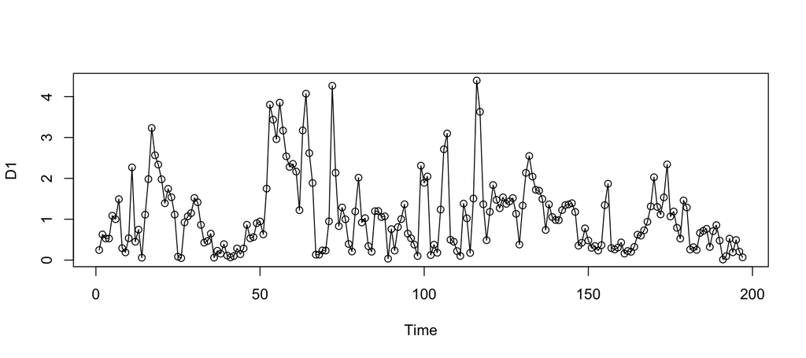

```r
    D  <- read.csv("https://nmimoto.github.io/datasets/copper.csv")
    D1 <- ts(D[,2], start=1)    #- extract only second column as time series
    plot(D1, type="o")
```

```r
    library(forecast)

    #   ?Arima    # open help page for Arima()

    auto.arima(D1)
```

```
## Series: D1
## ARIMA(1,0,3) with non-zero mean
##
## Coefficients:
##          ar1      ma1      ma2      ma3    mean
##       0.8695  -0.0925  -0.2958  -0.1809  1.0607
## s.e.  0.0865   0.1129   0.0921   0.0751  0.1590
##
## sigma^2 estimated as 0.4809:  log likelihood=-205.24
## AIC=422.47   AICc=422.91   BIC=442.17
```

```r
    #- Default is CSS-ML
    Arima(D1, order=c(1,0,3))
```

```
## Series: D1
## ARIMA(1,0,3) with non-zero mean
##
## Coefficients:
##          ar1      ma1      ma2      ma3    mean
##       0.8695  -0.0925  -0.2958  -0.1809  1.0607
## s.e.  0.0865   0.1129   0.0921   0.0751  0.1590
##
## sigma^2 estimated as 0.4809:  log likelihood=-205.24
## AIC=422.47   AICc=422.91   BIC=442.17
```

```r
    #- See what CSS gave
    Arima(D1, order=c(1,0,3), method="CSS")
```

```
## Series: D1
## ARIMA(1,0,3) with non-zero mean
##
## Coefficients:
##          ar1      ma1      ma2      ma3    mean
##       0.8570  -0.0780  -0.2870  -0.1784  1.1006
## s.e.  0.0889   0.1146   0.0916   0.0738  0.1577
##
## sigma^2 estimated as 0.479:  part log likelihood=-205
```

```r
    #- perform MLE with different initial value
    Arima(D1, order=c(1,0,3), method="ML", init=c(.6, -.1, -.3, .2, 20))
```

```
## Series: D1
## ARIMA(1,0,3) with non-zero mean
##
## Coefficients:
```

```
##          ar1      ma1      ma2     ma3     mean
##       0.9998  -0.3018  -0.3959  0.0291  19.9009
## s.e.     NaN   0.0738   0.0618  0.0741      NaN
##
## sigma^2 estimated as 0.5394:  log likelihood=-219.19
## AIC=450.38   AICc=450.82   BIC=470.08
```

```r
    # Arima(D1, order=c(1,0,3), method="ML", init=c(.8, -.5, -.3, .2, 2))  # gives error

    Arima(D1, order=c(1,0,3), method="ML", init=c(.7, -.5, -.3, .2, 2))
```

```
## Series: D1
## ARIMA(1,0,3) with non-zero mean
##
## Coefficients:
##          ar1      ma1      ma2      ma3    mean
##       0.8695  -0.0926  -0.2958  -0.1809  1.0606
## s.e.  0.0865   0.1129   0.0921   0.0751  0.1590
##
## sigma^2 estimated as 0.4809:  log likelihood=-205.24
## AIC=422.47   AICc=422.91   BIC=442.17
```

# 2. Example: Wave tank data

Cowpartwait Ch6.5 The data in the file wave.dat are the surface height of water (mm), relative to the still water level, measured using a capacitance probe positioned at the centre of a wave tank. The continuous voltage signal from this capacitance probe was sampled every 0.1 second over a 39.6-second period. The objective is to fit a suitable ARMA(p, q) model that can be used to generate a realistic wave input to a mathematical model for an ocean-going tugboat in a computer simulation. The results of the computer simulation will be compared with tests using a physical model of the tugboat in the wave tank.

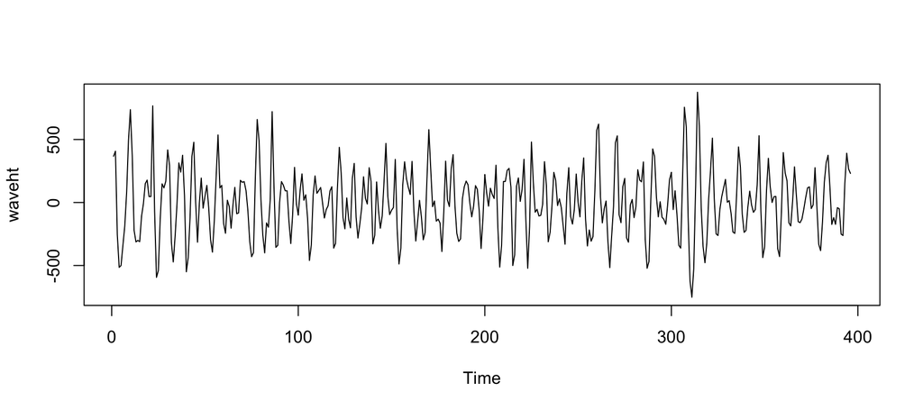

```r
  D <- read.csv("https://nmimoto.github.io/datasets/wave.csv", header=T)
  Wave <- ts(D, start=c(1,1), freq=1)

  library(forecast)
  plot(Wave)
```

```r
  source('https://nmimoto.github.io/R/TS-00.txt')

  Fit1 <- auto.arima(Wave, d=0)
  Fit1
```

```
## Series: Wave
## ARIMA(3,0,5) with non-zero mean
##
## Coefficients:
##          ar1      ar2     ar3      ma1     ma2     ma3     ma4      ma5     mean
##       1.8624  -1.3719  0.2980  -1.6133  0.0287  0.7688  0.1794  -0.3429  -5.0000
## s.e.  0.1110   0.1670  0.0988   0.1047  0.1540  0.1065  0.1353   0.0645   0.7079
##
## sigma^2 estimated as 19886:  log likelihood=-2520
## AIC=5060.01   AICc=5060.58   BIC=5099.82
```

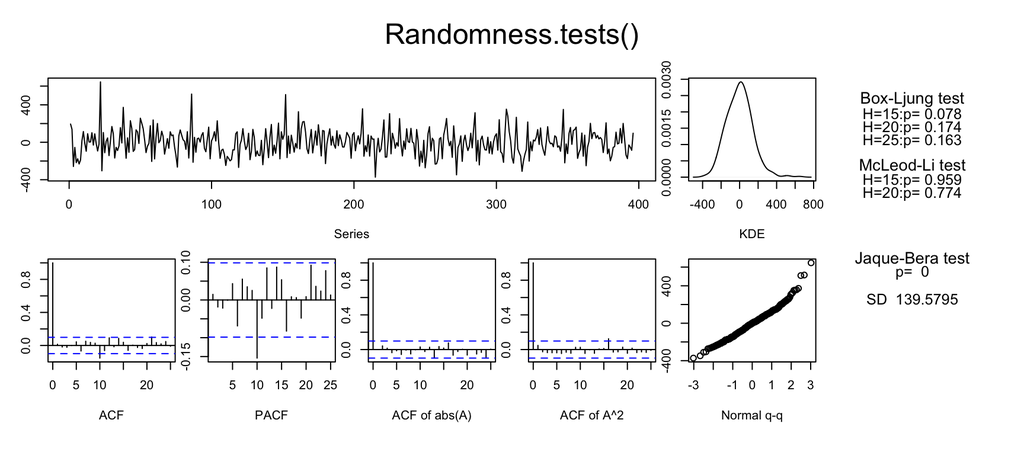

```
##   B-L test H0: the sereis is uncorrelated
##   M-L test H0: the square of the sereis is uncorrelated
##   J-B test H0: the sereis came from Normal distribution
##   SD         : Standard Deviation of the series
```

```
##       BL15  BL20  BL25  ML15  ML20 JB      SD
## [1,] 0.078 0.174 0.163 0.959 0.774  0 139.579
```

```r
  Randomness.tests(Fit1$resid)
```

```r
  #Fit ARMA(3,5) with theta2 and theta4 =0  (Phis, Thetas, Mean).
  Fit2 <- Arima(Wave, order=c(3,0,5), fixed=c(NA,NA,NA,  NA,0,NA,0,NA,  NA ) )
  Fit2
```

```
## Series: Wave
## ARIMA(3,0,5) with non-zero mean
##
## Coefficients:
##          ar1     ar2     ar3      ma1  ma2     ma3  ma4      ma5     mean
##       1.8743  -1.395  0.3101  -1.6210    0  0.9117    0  -0.2695  -4.9952
## s.e.  0.0629   0.092  0.0571   0.0343    0  0.0650    0   0.0369   0.7309
##
## sigma^2 estimated as 19933:  log likelihood=-2521.46
## AIC=5058.93   AICc=5059.3   BIC=5090.78
```

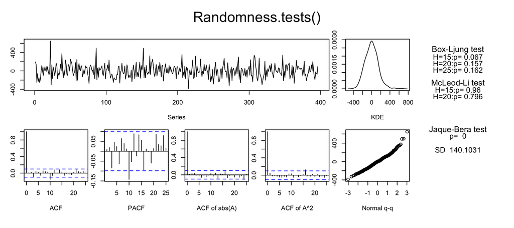

```
##   B-L test H0: the sereis is uncorrelated
##   M-L test H0: the square of the sereis is uncorrelated
##   J-B test H0: the sereis came from Normal distribution
##   SD         : Standard Deviation of the series
```

```
##       BL15  BL20  BL25 ML15  ML20 JB      SD
## [1,] 0.067 0.157 0.162 0.96 0.796  0 140.103
```

```r
  Randomness.tests(Fit2$resid)
```

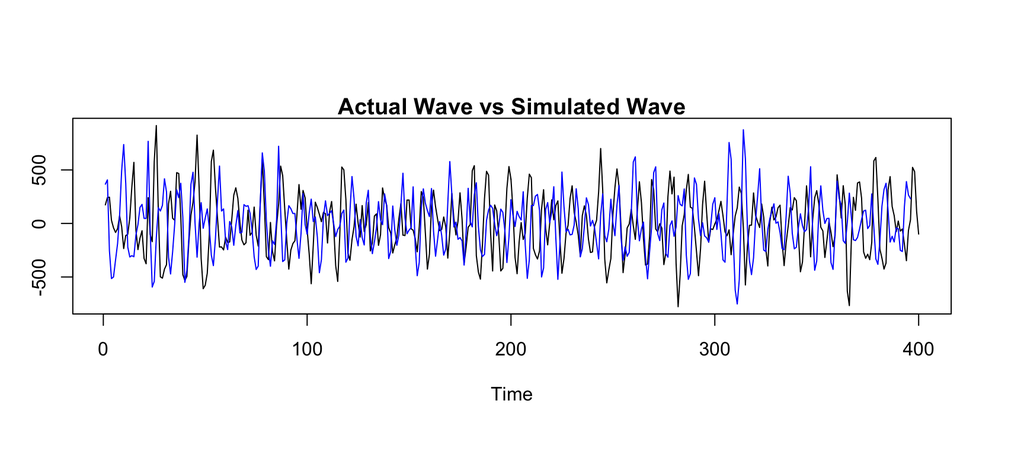

```r
  #- Simulating Waves ---
  X <- arima.sim( n=400, list(ar=Fit2$coef[1:3], ma=Fit2$coef[4:8]),
                  sd=sqrt(Fit2$sigma2) )  +  Fit2$coef[9]
  ts.plot(X,Wave, col=c("black","blue"), main="Actual Wave vs Simulated Wave")
```

# Summary

[TS Class Web Page](https://nmimoto.github.io/477/) – [R resource page](https://nmimoto.github.io/R/)